# STATS 504 HW 2

Steven Hwang

January 23, 2017

## Part I

What affects the price of a Airbnb listing in Amsterdam?

http://insideairbnb.com/get-the-data.html

The data comes from inside Airbnb a independent, non-commercial set of data that allows you to explore how Airbnb is being used in cities around the world. The data was collected using web scrapers to collect publicly available data on Airbnb. After cleaning the data, there are 13849 cases and 95 variables. The variables range from accomodation descriptions, to price, to review ratings, and host response rate & acceptance rate.

Some of the covariates are:

1. Host response rate = How often the host responds to messages
2. Host acceptance rate = How often the host accepts bookings requests
3. Number it accomodates
4. Number of bathrooms
5. Number of bedrooms
6. Number of beds
7. Price = price per night
8. Type of Amenities = A list of the type of amenities
9. Number of guests included = Number of guests included with the price
10. Number of reviews
11. Review score rating = Overall review rating score out of 100
12. Review score accuracy = Accuracy of the description
13. Review score communication
14. Review score cleanliness
15. Review score location
16. Review score check-in = How was the check in process
17. Review score value = How was the price for the accomodation
18. Reviews per month
19. Property type
20. Room type

[output not shown]

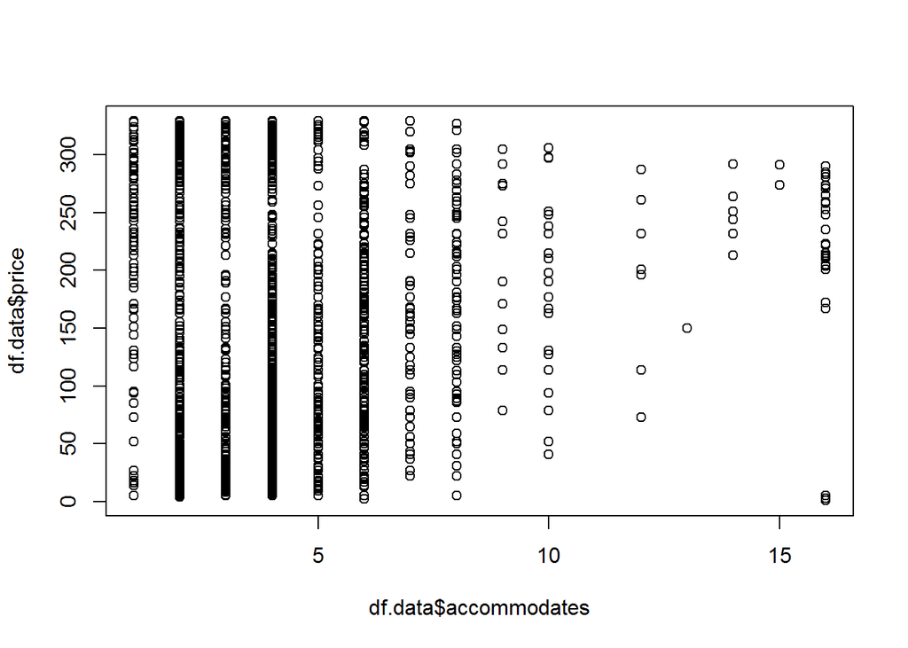

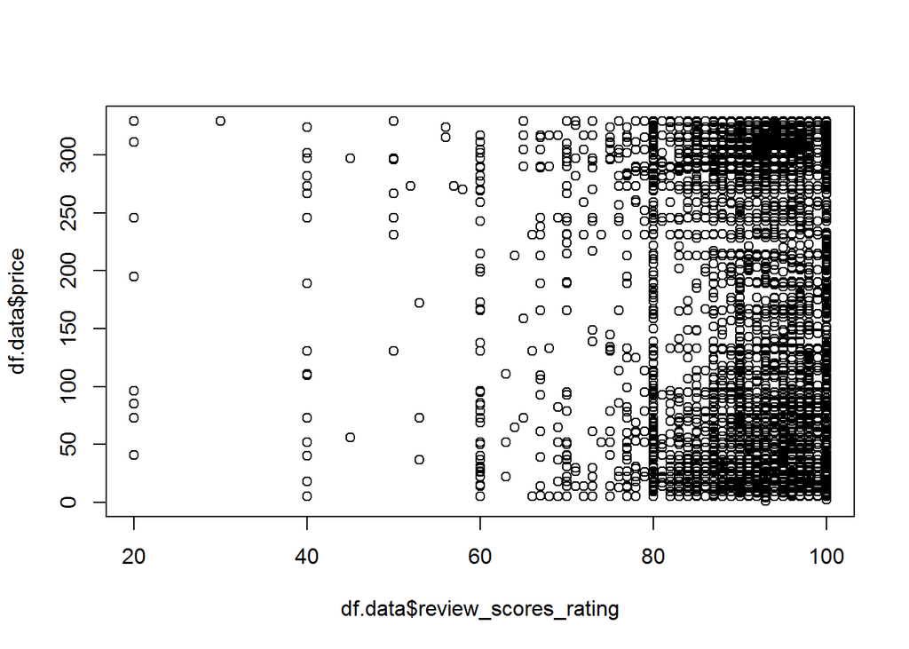